# Trabalho de R - Relação Entre Algumas Estatísticas de Filmes e sua Percepção pelo Público

Igor Schiavo Pedro

2025-10-03

## Introdução:

Esta análise investiga como o ano de lançamento e a duração dos filmes influenciam suas avaliações no IMDb, utilizando técnicas de regressão linear para identificar relações significativas entre essas variáveis.

## 1)Bibliotecas Usadas

```r
library(tidyverse)
```

```r
library(ggplot2)
```

## 2)Importação e verificação dos dados

Aqui, usei como fonte as bases de dados do IMDB para fins não comerciais.

```r
notas <- read.delim("C:/Users/Lenovo/Downloads/title.ratings.tsv/title.ratings.tsv", sep = "\t",
                    header = TRUE,
                    quote = "",
                    fill = TRUE,
                    na.strings = "\\N")

# Verifique as primeiras linhas dos dados
head(notas)
```

```
##      tconst averageRating numVotes
## 1 tt0000001           5.7     2180
## 2 tt0000002           5.5      302
## 3 tt0000003           6.4     2252
## 4 tt0000004           5.2      195
## 5 tt0000005           6.2     2994
## 6 tt0000006           5.0      221
```

```r
str(notas)
```

```
## 'data.frame':    1619387 obs. of  3 variables:
##  $ tconst       : chr  "tt0000001" "tt0000002" "tt0000003" "tt0000004" ...
##  $ averageRating: num  5.7 5.5 6.4 5.2 6.2 5 5.3 5.3 5.4 6.8 ...
##  $ numVotes     : int  2180 302 2252 195 2994 221 930 2339 228 8090 ...
```

```r
dados <- read.delim("C:/Users/Lenovo/Downloads/title.basics.tsv/title.basics.tsv",
                    sep = "\t",
                    header = TRUE,
                    quote = "",
                    fill = TRUE,
                    na.strings = "\\N")

# Verifique as primeiras linhas dos dados
head(dados)
```

```
##      tconst titleType           primaryTitle          originalTitle isAdult
## 1 tt0000001     short             Carmencita             Carmencita       0
## 2 tt0000002     short Le clown et ses chiens Le clown et ses chiens       0
## 3 tt0000003     short           Poor Pierrot         Pauvre Pierrot       0
## 4 tt0000004     short            Un bon bock            Un bon bock       0
## 5 tt0000005     short       Blacksmith Scene       Blacksmith Scene       0
## 6 tt0000006     short      Chinese Opium Den      Chinese Opium Den       0
##   startYear endYear runtimeMinutes                   genres
## 1      1894      NA              1        Documentary,Short
## 2      1892      NA              5          Animation,Short
## 3      1892      NA              5 Animation,Comedy,Romance
## 4      1892      NA             12          Animation,Short
## 5      1893      NA              1                    Short
## 6      1894      NA              1                    Short
```

```r
str(dados)
```

```
## 'data.frame':    11946100 obs. of  9 variables:
##  $ tconst        : chr  "tt0000001" "tt0000002" "tt0000003" "tt0000004" ...
##  $ titleType     : chr  "short" "short" "short" "short" ...
##  $ primaryTitle  : chr  "Carmencita" "Le clown et ses chiens" "Poor Pierrot" "Un bon bock" ...
##  $ originalTitle : chr  "Carmencita" "Le clown et ses chiens" "Pauvre Pierrot" "Un bon bock" ...
##  $ isAdult       : int  0 0 0 0 0 0 0 0 0 0 ...
##  $ startYear     : int  1894 1892 1892 1892 1893 1894 1894 1894 1894 1895 ...
##  $ endYear       : int  NA NA NA NA NA NA NA NA NA NA ...
##  $ runtimeMinutes: int  1 5 5 12 1 1 1 1 45 1 ...
##  $ genres        : chr  "Documentary,Short" "Animation,Short" "Animation,Comedy,Romance" "Animation,Short" ...
```

```r
unique(dados$titleType)
```

```
##  [1] "short"        "movie"        "tvShort"      "tvMovie"      "tvEpisode"
##  [6] "tvSeries"     "tvMiniSeries" "tvSpecial"    "video"        "videoGame"
## [11] "tvPilot"
```

## 3)Transformações e limpeza

```r
#queremos apenas os filmes
dados_filmes<-dados %>% filter(titleType== "movie", startYear>=1970)

#Removamos colunas desnecessárias
dados_filmes <- dados_filmes %>%
  select(tconst, startYear, runtimeMinutes)
notas <- notas%>%
  select(tconst,averageRating)

dados_completos <- dados_filmes %>%
  inner_join(notas, by = "tconst")
dados_completos <- dados_completos %>%
  filter(!is.na(runtimeMinutes))
# Remover outliers distorcivos
limite_inferior <- quantile(dados_completos$runtimeMinutes, 0.01, na.rm = TRUE)
limite_superior <- quantile(dados_completos$runtimeMinutes, 0.99, na.rm = TRUE)

dados_filtrados <- dados_completos %>%
  filter(runtimeMinutes >= limite_inferior & runtimeMinutes <= limite_superior)
str(dados_filtrados)
```

```
## 'data.frame':    246132 obs. of  4 variables:
##  $ tconst        : chr  "tt0015724" "tt0035423" "tt0036606" "tt0038687" ...
##  $ startYear     : int  1993 2001 1983 1980 1973 1977 1971 1971 1972 1983 ...
##  $ runtimeMinutes: int  102 118 118 58 88 127 116 92 105 84 ...
##  $ averageRating : num  6.3 6.4 6.4 7.4 6.1 7.9 6.3 3.6 7.5 4 ...
```

## 4) Gráficos

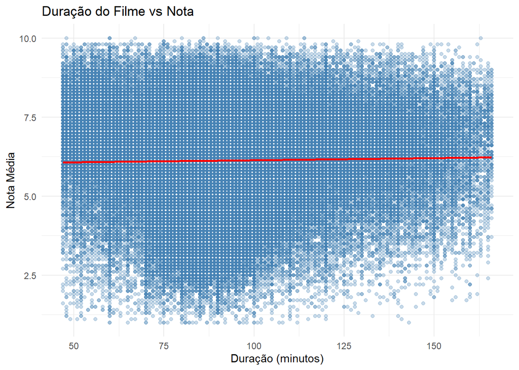

```r
# Gráfico de dispersão com linha de tendência
ggplot(dados_filtrados, aes(x = runtimeMinutes, y = averageRating)) +
  geom_point(alpha = 0.3, color = "steelblue") +
  geom_smooth(method = "lm", color = "red", se = TRUE) +
  labs(title = "Duração do Filme vs Nota",
       x = "Duração (minutos)",
       y = "Nota Média") +
  theme_minimal()
```

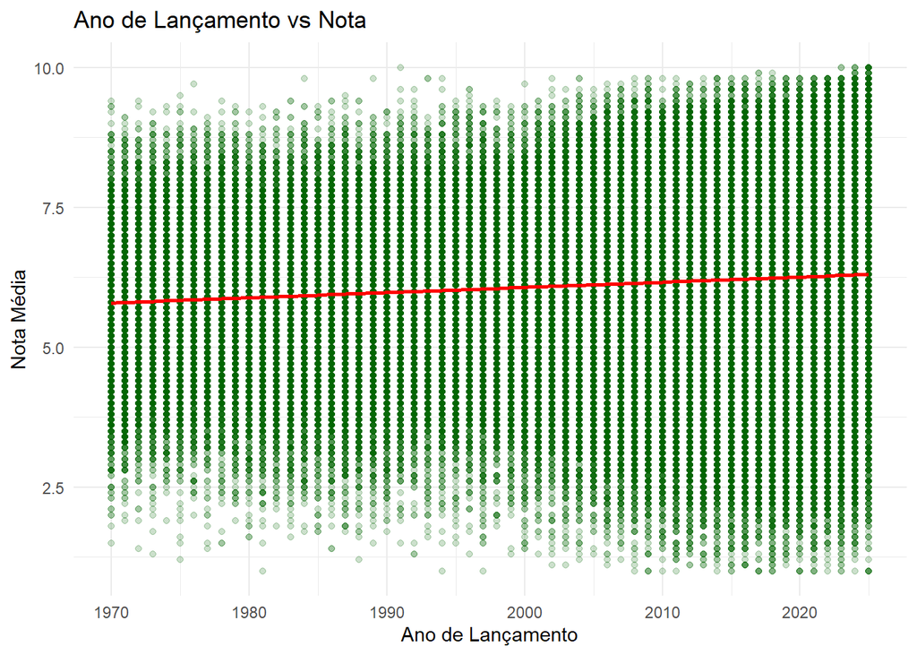

```r
ggplot(dados_filtrados, aes(x = startYear, y = averageRating)) +
  geom_point(alpha = 0.2, color = "darkgreen") +
  geom_smooth(method = "lm", color = "red", se = TRUE) +
  labs(title = "Ano de Lançamento vs Nota",
       x = "Ano de Lançamento",
       y = "Nota Média") +
  theme_minimal()
```

Esses gráficos nos dão uma ideia de como o público gosta de filmes baseado no tempo de duração e data de lançamento. Havendo uma relação fraca, mas perceptível, especialmente no segundo caso.

## 5)Regressão

```r
modelo <- lm(averageRating ~ I(startYear-1970) + runtimeMinutes, data = dados_filtrados)

# Ver resumo do modelo
summary(modelo)
```

```
##
## Call:
## lm(formula = averageRating ~ I(startYear - 1970) + runtimeMinutes,
##     data = dados_filtrados)
##
## Residuals:
##     Min      1Q  Median      3Q     Max
## -5.3273 -0.8687  0.1152  0.9747  4.0243
##
## Coefficients:
##                      Estimate Std. Error t value Pr(>|t|)
## (Intercept)         5.6695709  0.0145982 388.375   <2e-16 ***
## I(startYear - 1970) 0.0092452  0.0001865  49.564   <2e-16 ***
## runtimeMinutes      0.0013019  0.0001341   9.711   <2e-16 ***
## ---
## Signif. codes:  0 '***' 0.001 '**' 0.01 '*' 0.05 '.' 0.1 ' ' 1
##
## Residual standard error: 1.402 on 246129 degrees of freedom
## Multiple R-squared:  0.01028,    Adjusted R-squared:  0.01027
## F-statistic:  1278 on 2 and 246129 DF,  p-value: < 2.2e-16
```

Ao rodarmos essa regressão, quantificamos a relação mostrada pelos gráficos anteriores entre a “qualidade” de um filme e algumas de suas características. Os resultados da regressão indicam que os usuários do IMDb tendem a dar notas mais altas a filmes mais recentes e de maior duração. Esse padrão pode estar associado a diferentes fatores. No caso dos filmes recentes, existe um viés de popularidade, já que os lançamentos recebem maior atenção da mídia e do público, gerando avaliações mais positivas em função do entusiasmo inicial. Além disso, o perfil dos avaliadores do IMDb é predominantemente jovem e mais conectado ao consumo contemporâneo de cinema, o que pode favorecer produções atuais. Soma-se a isso o fato de que a indústria cinematográfica tem avançado em tecnologia e qualidade técnica, o que contribui para elevar a percepção de qualidade nos títulos mais novos. Quanto à duração, filmes mais longos costumam estar associados a orçamentos maiores, elencos renomados e propostas narrativas mais ambiciosas. Existe também a percepção de que um filme extenso requer maior inteligência para compreensão ( em geral), o que pode influenciar positivamente as avaliações sem necessariamente contar com conteúdo de maior qualidade. Por fim, é importante destacar que esse resultado pode estar condicionado a viéses da base de dados: muitos filmes antigos e medianos caem no esquecimento e não chegam a ser avaliados, enquanto gêneros mais longos, como épicos e dramas, já tendem a ter recepção crítica mais favorável. Assim, os efeitos observados refletem tanto transformações na produção cinematográfica quanto preferências e limitações da comunidade de votantes do IMDb. Além disso, o R2 da regressão ainda foi bem baixo, o que indica que essas variáveis por si só não explicam bem o gosto da audiência cinéfila, requerindo a presença de outras variáveis para um grau de ajuste mais robusto.

## Glossário:

### runtimeMinutes:

Duração do filme, em minutos;

### startYear:

Ano de lançamento do filme;

### tconst:

Identificador alfanumérico único do título;

### averageRating:

Nota do filme no IMDB;

### titleType:

Tipo de produção, seja curta, série, filme para tv etc.

## Como Reproduzir:

Primeiramente, garanta que tem instalados todas as bibliotecas necessárias. São estas tidiyverse (limpeza e manipulação de dados) e ggplot2 (visualização gráfica dos dados). Caso não tenha, use install.packages() para cada uma destas, seguido de library().

## Referências:

Essas bases estão dentre as expostas no link a seguir: https://datasets.imdbws.com/